# Reducción Dimensionalidad - PCA: MercadoHipotecas

INE-S.G. Difusión

# Introducción

## dataset

En este cuaderno vamos a analizar el dataset llamado [*MercadoHipotecas.xlsx*](https://github.com/davidperezros/ine_sg_difusion_explica_datasets/blob/aa4094c2592ae20139130220c6658c8ab58b1037/Datasets/MercadoHipotecas.xlsx). Este dataset presenta los datos de estudio del mercado de adquisición de viviendas en propiedad en todas las comunidades autónomas durante el ejercicio 2021, relacionando las transmisiones inmobiliarias con las hipotecas constituidas, los índices de precio de vivienda y otras variables económicas y sociodemográficas. Orientado a escalamiento multidimensional, técnicas de clusterización y análisis de componentes principales. Nuestro **objetivo** es aplicar un procedimiento de PCA para conocer que variables independientes son de interés para estudiar el mercado inmobiliario y ver qué comunidades autónomas son las más parecidas y las más diferentes en términos de variables hipotecarias y sociodemográficas. Concretamente en este dataset tenemos las siguientes variables:

- **CCAA**: Comunidades Autónomas.
- **HipotecaMedia**: Importe de la hipoteca por cada comunidad autonoma promediadas por su tanaño.
- **IndicedeVivienda**: Índice del precio de la vivienda (IPV).
- **TasaEjecHipotecarias**: Número de Hipotecas Ejecutadas.
- **Hip100H**: Número de hipotecas por cada cien mil habitantes en la comunidad autónoma.
- **TasaParo**: Tasas de paro por distintos grupos de edad, sexo y comunidad autónoma.
- **TasaNatalidad**: Tasa Bruta de Natalidad.
- **NumHip**: Cantidad de hipótecas en la comunidad autónoma.
- **VV100H**: Número de viviendas vacias por cada cien mil habitantes.
- **IndEnvej**: Porcentaje de personas mayores a 65 años.
- **TasaMortalidad**: Porcentaje de fallecidos por comunidad autónoma.
- **TasaFecundidad**: Tasa Global de Fecundidad por comunidad autónoma, según nacionalidad (española/extranjera) de la madre.
- **Activos**: Persona mayor de 16 años en búsqueda activa de trabajo .
- **Compravent**: Número de compraventas por comunidad autónoma.

Si tomamos demasiadas variables es difícil visualizar relaciones entre ellas. Otro problema que se presenta es la fuerte correlación. Se hace necesario, pues, reducir el número de variables sin perder información. Es importante resaltar el hecho de que el concepto de mayor información se relaciona con el de mayor variabilidad o varianza.

```r
# Librerias
library(readxl) # Para leer los excels
library(dplyr) # Para tratamiento de dataframes
library(ggplot2) # Nice plots
library(factoextra) # fviz_cluster function
library(skimr)  # Para funcion skim
library(ggcorrplot) #Para funcion ggcorrplot
library(corrplot) #Para corrplot
```

Cargamos entonces el conjunto de datos:

```r
datos <- read_excel("/Users/davpero/ine_sg_difusion_explica_datasets/Datasets/MercadoHipotecas.xlsx", sheet = "Datos")
```

## Descripción del trabajo a realizar

**(Esto irá en la web de explica)** Se pretende hacer un Análisis de Reducción de la Dimensionalidad empleando el procedimiento de Componentes Principales. El objetivo es conocer que variables independientes son de interés para estudiar el mercado inmobiliario y ver qué comunidades autónomas son las más parecidas y las más diferentes en términos de variables hipotecarias y sociodemográficas.

- Hacer un análisis exploratorio explorando matriz de correlaciones.
- Ver si es necesario escalar/centrar los datos antes de aplicar pca y decidir si hacerlo con matriz de correlaciones o covarianzas.
- Seleccionar un determinado número de componentes y ver como influyen las variables en estas.
- Interpretar componentes y resultados.

# Análisis Exploratorio (EDA[^1])

En primer lugar, cargamos los datos que vamos a utilizar. En este caso, se trata de un conjunto de datos compuesto por 19 filas y 14 columnas. Las filas corresponden a las 19 Comunidades Autónomas de España y las 14 columnas a variables que se han medido para cada una de ellas.

Antes de comenzar a aplicar la técnica, comprobamos si hay valores perdidos, por si fuera necesario realizar algún preproceso. En este caso, y como vemos a continuación, no hay ningún NA en los datos que vamos a utilizar.

```r
sum(is.na(datos))
```

```
## [1] 0
```

Por otra parte, para tener una noción general que nos permita describir el conjunto con el que vamos a trabajar, podemos extraer su dimensión, el tipo de variables que contiene o qué valores toma cada una.

```r
# Dimensión del conjunto de datos
dim(datos)
```

```
## [1] 19 14
```

```r
# Tipo de variables que contiene
str(datos)
```

```
## tibble [19 × 14] (S3: tbl_df/tbl/data.frame)
##  $ CCAA                : chr [1:19] "Andalucía" "Aragón" "Asturias" "Baleares" ...
##  $ HipotecaMedia       : num [1:19] 125016 124092 104138 249109 137260 ...
##  $ IndicedeVivienda    : num [1:19] 0.952 0.94 0.901 1.09 0.953 ...
##  $ TasaEjecHipotecarias: num [1:19] 0.2299 0.0195 0.0163 0.0108 0.044 ...
##  $ Hip100H             : num [1:19] 1297 1167 1087 1109 808 ...
##  $ TasaParo            : num [1:19] 21.7 10.2 12.5 14.9 23.2 ...
##  $ TasaNatalidad       : num [1:19] 7.72 7.21 4.74 7.81 5.67 5.63 5.5 7.1 7.52 7.06 ...
##  $ NumHip              : num [1:19] 109869 15475 10994 13013 17547 ...
##  $ VV100H              : num [1:19] 7521 7565 8189 6075 6363 ...
##  $ IndEnvej            : num [1:19] 108 148 231 106 126 ...
##  $ TasaMortalidad      : num [1:19] 9.33 11.06 13.25 7.22 7.63 ...
##  $ TasaFecundidad      : num [1:19] 34.4 34.8 24.7 32.7 23.9 ...
##  $ Activos             : num [1:19] 4023 645 447 649 1121 ...
##  $ Compravent          : num [1:19] 117987 14935 9406 14168 20801 ...
```

```r
# Descripción de las variables
skim(datos)
```

Data summary

| Name | datos |
| --- | --- |
| Number of rows | 19 |
| Number of columns | 14 |
| _______________________ |  |
| Column type frequency: |  |
| character | 1 |
| numeric | 13 |
| ________________________ |  |
| Group variables | None |

**Variable type: character**

| skim_variable | n_missing | complete_rate | min | max | empty | n_unique | whitespace |
| --- | --- | --- | --- | --- | --- | --- | --- |
| CCAA | 0 | 1 | 5 | 18 | 0 | 19 | 0 |

**Variable type: numeric**

| skim_variable | n_missing | complete_rate | mean | sd | p0 | p25 | p50 | p75 | p100 | hist |
| --- | --- | --- | --- | --- | --- | --- | --- | --- | --- | --- |
| HipotecaMedia | 0 | 1 | 133388.65 | 42665.06 | 91787.81 | 105374.29 | 120524.54 | 144500.61 | 249109.28 | ▇▃▂▁▁ |
| IndicedeVivienda | 0 | 1 | 0.96 | 0.09 | 0.82 | 0.90 | 0.94 | 1.01 | 1.12 | ▂▇▂▁▅ |
| TasaEjecHipotecarias | 0 | 1 | 0.05 | 0.07 | 0.00 | 0.01 | 0.02 | 0.05 | 0.23 | ▇▂▁▁▁ |
| Hip100H | 0 | 1 | 1073.97 | 234.29 | 393.93 | 993.02 | 1109.37 | 1231.59 | 1407.47 | ▁▁▂▇▅ |
| TasaParo | 0 | 1 | 14.94 | 4.96 | 9.84 | 11.49 | 12.52 | 17.74 | 26.66 | ▇▃▂▂▁ |
| TasaNatalidad | 0 | 1 | 7.17 | 1.49 | 4.74 | 6.12 | 7.10 | 7.75 | 11.17 | ▇▇▇▂▁ |
| NumHip | 0 | 1 | 29379.47 | 33716.23 | 329.00 | 8910.00 | 17126.00 | 26166.00 | 109869.00 | ▇▂▁▁▂ |
| VV100H | 0 | 1 | 7214.38 | 3019.69 | 1584.73 | 5568.22 | 7565.40 | 9907.24 | 11177.44 | ▂▃▃▇▇ |
| IndEnvej | 0 | 1 | 134.11 | 46.60 | 46.23 | 110.60 | 126.11 | 153.13 | 231.07 | ▂▆▇▂▃ |
| TasaMortalidad | 0 | 1 | 9.72 | 1.89 | 6.76 | 8.25 | 9.83 | 10.93 | 13.25 | ▆▇▆▅▅ |
| TasaFecundidad | 0 | 1 | 32.89 | 5.33 | 23.90 | 30.72 | 32.91 | 34.61 | 47.19 | ▃▇▅▁▁ |
| Activos | 0 | 1 | 1221.23 | 1283.45 | 36.30 | 381.95 | 748.30 | 1174.60 | 4022.90 | ▇▃▁▁▂ |
| Compravent | 0 | 1 | 29815.00 | 34610.46 | 308.00 | 8529.50 | 19785.00 | 24230.50 | 117987.00 | ▇▁▁▂▁ |

Vemos que estas variables (a excepción de las CCAA) son todas de tipo numérico, y además, podemos obtener información como la media, desviación típica, los cuartiles y el histograma de cada una.

**Correlación:** El que existan correlaciones muy elevadas en el conjunto de datos nos permitirá resumir la información en un menor número de componentes principales, pues éstas explicarán una mayor cantidad de información.

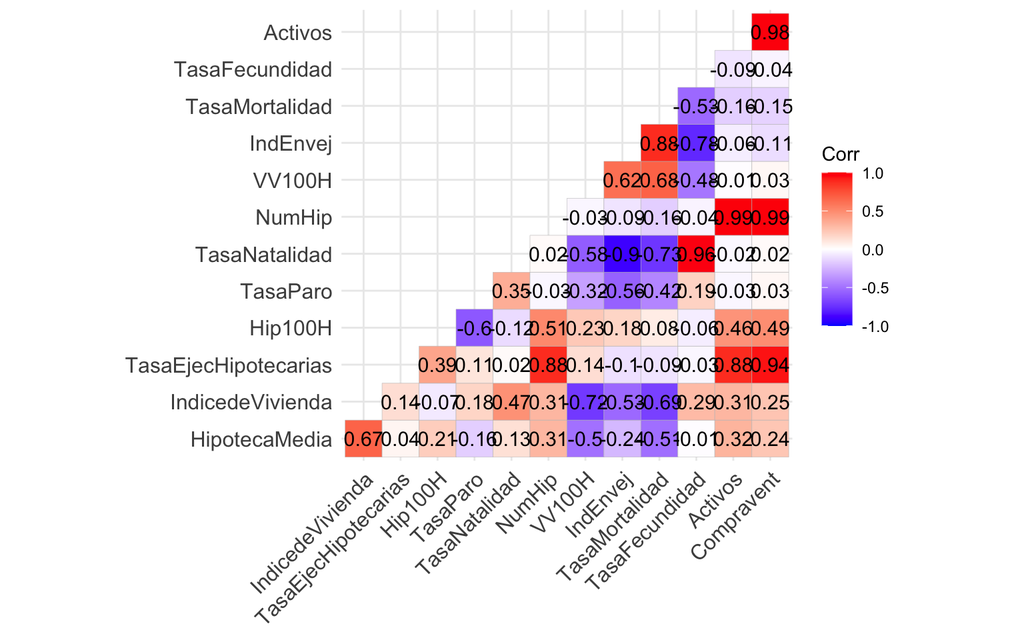

```r
ggcorrplot(cor(datos[,2:14]), type = "lower", lab = T, show.legend = T)
```

En este caso, se ha generado un gráfico entre variables, sin tener en cuenta la correlación de la variable consigo misma, pues siempre será del 100%.

En resumen, vemos que hay varias variables con una alta correlación absoluta(tanto postivia como negativa), luego esto nos va a permitir resumir la información en un núemro de componentes principales menor al número de variables que aquí tenemos.

# Reducción Dimensionalidad: Componentes Principales

## Introducción

El **Análisis de Componentes Principales (PCA)** es una técnica para reducir la complejidad de conjuntos de datos con múltiples variables. Su objetivo es transformar variables correlacionadas en un conjunto menor de dimensiones sin perder la mayor parte de la información original.

Se busca encontrar **nuevas variables (componentes)** que estén incorrelacionadas y que capturen la máxima variabilidad de los datos. Esto se logra mediante combinaciones lineales de las variables originales. PCA es útil para entender relaciones, reducir dimensiones y manejar la alta correlación entre variables.

Para aplicar PCA, se necesitan **datos cuantitativos** y es crucial *escalar las variables* (estandarizar = media cero y varianza uno). Esto garantiza que ninguna variable domine el análisis. Además, se puede trabajar con la matriz de correlaciones para abordar fuertes correlaciones entre variables, manteniendo así la información más relevante del conjunto de datos.

Los pasos generales son:

1. **Estandarización de las variables**: Es importante estandarizar las variables numéricas para que tengan media cero y desviación estándar uno. Esto es crucial para que ninguna variable domine el análisis debido a su escala.
2. **Cálculo de la matriz de correlaciones o covarianzas**: Dependiendo del enfoque, se puede trabajar con la matriz de correlaciones si se busca abordar fuertes correlaciones entre variables, o con la matriz de covarianzas si se busca la varianza total de las variables.
- **NOTA**: Aconsejable trabajar siempre con la matriz de correlaciones (a no ser que todas variables estén en las mismas unidades, que se podrá usar la matriz de covarianzas). De no seguir esta nota y usar la matriz de covarianzas, las variables que tienen mayores unidades dominarán la estructura de covarianza, lo que llevará a una representación inexacta de la variabilidad real de los datos.
3. **Descomposición de la matriz**: Se descompone la matriz de correlaciones en sus vectores y valores propios. Los valores propios representan la cantidad de varianza explicada por cada componente principal, mientras que los vectores propios (autovectores) determinan la dirección de cada componente en el espacio multidimensional original.
4. **Selección de componentes**: Los componentes se ordenan de manera descendente según la cantidad de varianza que explican. Los primeros componentes capturan la mayor variabilidad de los datos y se seleccionan para reducir la dimensionalidad manteniendo la información más relevante.
5. **Transformación de datos**: Proyectar los datos originales en el espacio de los componentes principales para obtener las nuevas variables. Estas son combinaciones lineales de las variables originales y son ortogonales entre sí. Esta transformación lineal **conserva la mayor parte de la información en un espacio de menor dimensión, lo que facilita el análisis y la visualización de los datos**.
6. **Interpretación y visualización**: Explorar la importancia de cada componente en términos de la variabilidad explicada. Se pueden interpretar los componentes para comprender qué aspectos de los datos capturan. Si es posible, representar gráficamente los datos en el espacio reducido de los componentes principales para obtener una mejor comprensión de las relaciones entre las observaciones.

## Modelo

En las siguientes lineas haremos que la variable `CCAA` se ponga como nombre de filas y posteriormente eliminaremos esa variable ya que ya la tendremos como nombre de filas.

```r
CCAA<-datos$CCAA
datos<-datos[,-1]         # Eliminamos ahora
rownames(datos)<-CCAA # Como nombres de filas las CCAA
```

Escalamos los datos y calculamos la matriz de varianzas covarianzas, mostramos solo la diagonal (debería ser 1).

```r
datos2<-scale(datos)
summary(datos2)
```

```
##  HipotecaMedia     IndicedeVivienda  TasaEjecHipotecarias    Hip100H
##  Min.   :-0.9751   Min.   :-1.5436   Min.   :-0.71140     Min.   :-2.9025
##  1st Qu.:-0.6566   1st Qu.:-0.6068   1st Qu.:-0.58520     1st Qu.:-0.3455
##  Median :-0.3015   Median :-0.1983   Median :-0.44917     Median : 0.1511
##  Mean   : 0.0000   Mean   : 0.0000   Mean   : 0.00000     Mean   : 0.0000
##  3rd Qu.: 0.2604   3rd Qu.: 0.5942   3rd Qu.:-0.05025     3rd Qu.: 0.6728
##  Max.   : 2.7123   Max.   : 1.8782   Max.   : 2.40454     Max.   : 1.4235
##     TasaParo       TasaNatalidad          NumHip             VV100H
##  Min.   :-1.0305   Min.   :-1.62684   Min.   :-0.86162   Min.   :-1.8643
##  1st Qu.:-0.6963   1st Qu.:-0.70550   1st Qu.:-0.60711   1st Qu.:-0.5451
##  Median :-0.4903   Median :-0.04549   Median :-0.36343   Median : 0.1162
##  Mean   : 0.0000   Mean   : 0.00000   Mean   : 0.00000   Mean   : 0.0000
##  3rd Qu.: 0.5640   3rd Qu.: 0.39005   3rd Qu.:-0.09531   3rd Qu.: 0.8918
##  Max.   : 2.3643   Max.   : 2.68165   Max.   : 2.38726   Max.   : 1.3124
##     IndEnvej       TasaMortalidad    TasaFecundidad         Activos
##  Min.   :-1.8856   Min.   :-1.5718   Min.   :-1.687729   Min.   :-0.92324
##  1st Qu.:-0.5044   1st Qu.:-0.7817   1st Qu.:-0.408172   1st Qu.:-0.65392
##  Median :-0.1716   Median : 0.0561   Median : 0.003953   Median :-0.36848
##  Mean   : 0.0000   Mean   : 0.0000   Mean   : 0.000000   Mean   : 0.00000
##  3rd Qu.: 0.4082   3rd Qu.: 0.6394   3rd Qu.: 0.324077   3rd Qu.:-0.03633
##  Max.   : 2.0806   Max.   : 1.8696   Max.   : 2.685109   Max.   : 2.18293
##    Compravent
##  Min.   :-0.8525
##  1st Qu.:-0.6150
##  Median :-0.2898
##  Mean   : 0.0000
##  3rd Qu.:-0.1614
##  Max.   : 2.5476
```

```r
diag(var(datos2))
```

```
##        HipotecaMedia     IndicedeVivienda TasaEjecHipotecarias
##                    1                    1                    1
##              Hip100H             TasaParo        TasaNatalidad
##                    1                    1                    1
##               NumHip               VV100H             IndEnvej
##                    1                    1                    1
##       TasaMortalidad       TasaFecundidad              Activos
##                    1                    1                    1
##           Compravent
##                    1
```

Aplicamos funcion PCA, notar que en este caso no haría falta los argumentos `SCALE=TRUE` y `CENTER=TRUE` puesto que ya hemos escalado dos datos en un paso previo. Por defecto en la función viene el valor de `SCALE=FALSE` y `CENTER=TRUE`.

```r
pca <- prcomp(datos2,center= TRUE,scale = TRUE)  # Scale=T
```

**Calculamos los coeficientes de la ecuación para cada componente principal**

```r
pca$rotation
```

```
##                              PC1         PC2         PC3         PC4
## HipotecaMedia         0.23447260 -0.06310254  0.60036701 -0.14352759
## IndicedeVivienda      0.35056462  0.03492200  0.33265184 -0.21595433
## TasaEjecHipotecarias  0.18895585 -0.38696171 -0.29859399 -0.04395518
## Hip100H               0.02384814 -0.32139415  0.21029632  0.52700520
## TasaParo              0.17638635  0.16978548 -0.45544384 -0.50048376
## TasaNatalidad         0.34697038  0.22377034 -0.16525154  0.33885102
## NumHip                0.23253409 -0.41264772 -0.06210480 -0.03592632
## VV100H               -0.31862705 -0.19954134 -0.24466170  0.14612450
## IndEnvej             -0.38398575 -0.20108861  0.16993058 -0.09362279
## TasaMortalidad       -0.39081025 -0.14283197 -0.08256307  0.03905432
## TasaFecundidad        0.27908332  0.21917010 -0.19293982  0.49563579
## Activos               0.22264109 -0.41490535 -0.05417093 -0.08779747
## Compravent            0.22610583 -0.41442757 -0.14564495 -0.03868128
##                              PC5         PC6         PC7         PC8
## HipotecaMedia         0.22721287  0.25793850  0.52980535  0.30139664
## IndicedeVivienda     -0.29883955  0.25484457 -0.69422079  0.26266824
## TasaEjecHipotecarias -0.04578494  0.09016705 -0.14237630 -0.14450223
## Hip100H               0.38422611 -0.46625149 -0.28074363  0.33169721
## TasaParo              0.26991529 -0.24907203  0.02930616  0.52896695
## TasaNatalidad        -0.10947984  0.16047629  0.05441172  0.12043767
## NumHip               -0.11719298 -0.06702702  0.13681214  0.03619294
## VV100H                0.39357805  0.72591201 -0.13624112  0.21415518
## IndEnvej             -0.29873692 -0.04475899 -0.01138938  0.04181744
## TasaMortalidad       -0.51193330 -0.04229536  0.15474088  0.56363472
## TasaFecundidad       -0.29559220  0.11660486  0.20014738  0.16672803
## Activos              -0.12111322  0.07773141  0.16598060 -0.14274555
## Compravent           -0.05002690 -0.01843676  0.07412227  0.01306008
##                               PC9          PC10        PC11          PC12
## HipotecaMedia        -0.262791756  0.0251241391 -0.01163925 -0.0004333459
## IndicedeVivienda      0.070224200 -0.0399012682  0.01986345 -0.0797306119
## TasaEjecHipotecarias -0.775723474 -0.0024548350 -0.13676702  0.0096868413
## Hip100H              -0.009941869  0.0447484933 -0.12820466 -0.0421913182
## TasaParo              0.030071820  0.2166825934 -0.06628922 -0.1170645772
## TasaNatalidad         0.036325847  0.3089459905 -0.21757169  0.6953808523
## NumHip                0.366200530 -0.0152004504  0.42093030  0.1793240415
## VV100H                0.153187336  0.0443334585  0.05124612 -0.0468669300
## IndEnvej             -0.054795835  0.8212580823  0.03498288 -0.0514083908
## TasaMortalidad       -0.085630316 -0.4010667812 -0.13596976  0.1584267923
## TasaFecundidad       -0.050617589  0.1249734888  0.15590775 -0.6136362733
## Activos               0.389029556  0.0153261020 -0.69630375 -0.2279291148
## Compravent            0.011356353  0.0002626747  0.45158656  0.0625588127
##                               PC13
## HipotecaMedia         0.0219537496
## IndicedeVivienda     -0.0113296319
## TasaEjecHipotecarias  0.2270146192
## Hip100H              -0.0002262752
## TasaParo              0.0252507795
## TasaNatalidad        -0.0674299774
## NumHip                0.6233573899
## VV100H                0.0302959223
## IndEnvej              0.0041371857
## TasaMortalidad       -0.0354555546
## TasaFecundidad        0.0577103822
## Activos              -0.1031295200
## Compravent           -0.7334418197
```

Podemos observar aquí nuestras variables en el nuevo sistema de cordenadas (las componentes principales), dando lugar a ecuaciones de cada eje como combinación lineal del total de variables. Analizar el vector que crea cada componente y cuáles son los pesos que tienen las variables en cada componente, ayuda a interpretar qué tipo de información recoge cada una de ellas.

$ PC_1 = 0.23 {HipotecaMedia} + 0.35 {IndicedeVivienda} + 0.18TasaEjecHipotecarias + 0.023 Hip100H + 0.17 TasaParo + 0.34 TasaNatalidad + 0.23 NumHip -0.31VV100H -0.38IndEnvej -0.39TasaMortalidad +0.27TasaFecundidad + 0.22Activos +0.22Compravent$

**Extraemos las nuevas coordenadas de los individuos (puntuaciones)**

Además, podemos ver las puntuaciones, que son las coordenadas de cada observación original (Comunidad Autónoma) sobre los nuevos ejes construidos (componentes principales). Esto corresponde a un cambio de coordenadas bajo el paradigma del Álgebra Lineal.

```r
 pca$x
```

```
##                           PC1         PC2         PC3         PC4          PC5
## Andalucía           2.7455023 -3.67317229 -2.12660745 -0.29682024  0.110706075
## Aragón             -0.9699327  0.32725095  0.46486382  1.06149710 -0.472663618
## Asturias           -3.5869740 -0.61984654  0.59178552 -0.75737644 -0.703643431
## Baleares            1.7825614  1.10268112  2.51261640 -0.46389719  1.035908384
## Canarias           -0.1301632  0.62843489 -0.23431304 -2.65430954  1.230373539
## Cantabria          -1.9979724 -0.01197302  0.82267569  0.26001624  0.450369088
## Castilla León      -2.7026848 -1.01136738 -0.11497356 -0.16914178 -0.536890298
## Castilla La Mancha -0.9290027  0.21256139 -0.74011673  0.53011163  0.848851231
## Cataluña            2.7389745 -2.91486340  0.52836881 -0.26063991 -0.837474574
## Cvalenciana         0.6478324 -2.73565870 -1.70915179  0.36886681  0.314182432
## Extremadura        -1.9681281  0.80998146 -1.49001512 -0.04715111  0.276129920
## Galicia            -2.8544978 -0.59320383 -0.13237242 -0.89058464 -0.786696609
## Madrid              3.3662356 -2.41685601  2.02910270  0.02964115 -0.009936487
## Murcia              0.6578774  1.18636724 -1.21821799  1.72054150  0.373052356
## Navarra            -0.1447226  1.41272907  0.68283945  0.99630793  0.118156816
## PaisVasco          -0.3644187 -0.15990677  1.81164513  0.51836980 -0.407434600
## La Rioja           -1.8046126  0.53640665 -0.04130292  1.11905222  0.441014002
## Ceuta               2.1698869  3.93962047 -0.87475999 -2.28618673 -0.795605090
## Melilla             3.3442391  3.98081471 -0.76206651  1.22170320 -0.648399135
##                             PC6         PC7         PC8         PC9        PC10
## Andalucía          -0.464167091  0.27301087  0.39570536  0.03036640  0.10008293
## Aragón              0.000578174 -0.05973468  0.11517510 -0.04716968 -0.17316784
## Asturias           -0.667474209 -0.26393758  0.26901900 -0.14543133  0.18368390
## Baleares            0.863799139  0.07742047  0.58825882 -0.41385644  0.15314700
## Canarias           -0.366682515 -0.15143184 -0.55567081  0.07533031  0.09050859
## Cantabria          -0.657556125 -0.93524427 -0.13942883  0.05217030 -0.13731336
## Castilla León       0.432311346 -0.07605104  0.01978793  0.02206576  0.14977190
## Castilla La Mancha  0.104829825  0.59710033  0.01973866  0.32991103 -0.18684983
## Cataluña            0.570424085  0.03427750 -0.30040647 -0.10886475 -0.19763763
## Cvalenciana         0.076833291 -0.42483946 -0.13046479 -0.67979305 -0.02854897
## Extremadura        -0.127527331  0.63183605  0.55695797  0.18377774  0.01817693
## Galicia             0.974657578  0.15586395 -0.28482319  0.23684134  0.15868031
## Madrid             -0.201133176 -0.16638968  0.00496925  0.68770653  0.05211501
## Murcia              0.284400425 -0.17269157 -0.35486145  0.14631769  0.08309741
## Navarra            -0.145413390  0.82387546 -0.70187692 -0.27220149  0.05649532
## PaisVasco          -0.941793203  0.63362573  0.04668404 -0.22152370 -0.09684373
## La Rioja            0.492628649 -0.52220202  0.26539476  0.12958325 -0.21612799
## Ceuta               0.047827143 -0.03390410  0.13400159 -0.05399996 -0.29299263
## Melilla            -0.276542616 -0.42058411  0.05183999  0.04877006  0.28372268
##                            PC11          PC12         PC13
## Andalucía           0.073488769 -0.0079224783 -0.029748511
## Aragón             -0.011186846 -0.0039848793 -0.025819489
## Asturias           -0.037865075  0.0905049079 -0.004029230
## Baleares            0.002150701  0.0066804364 -0.010156402
## Canarias           -0.075883351 -0.0244823013 -0.001124104
## Cantabria           0.020726590 -0.0290358175 -0.015005169
## Castilla León       0.069655256 -0.1046768332  0.010952963
## Castilla La Mancha -0.007564225  0.0149590302 -0.033822596
## Cataluña           -0.166811234 -0.0099003952 -0.002594989
## Cvalenciana         0.037928332  0.0171151462  0.023516428
## Extremadura        -0.098492637 -0.0145216149  0.038712801
## Galicia             0.027262055  0.0230609545 -0.015291536
## Madrid              0.068182987  0.0235482170  0.028696809
## Murcia             -0.025861394  0.0501499420  0.013033339
## Navarra             0.092609193  0.0121100316  0.005740842
## PaisVasco          -0.022083454 -0.0305590536  0.007893858
## La Rioja            0.019684769  0.0004476988  0.013228807
## Ceuta               0.092598574  0.0187605584  0.009238707
## Melilla            -0.058539011 -0.0322535498 -0.013422528
```

**Varianza explicada por cada componente principal**

Una vez calculadas las componentes principales, es de interés conocer la varianza explicada por cada una, ya que el principal objetivo que se sigue con PCA es maximizar la cantidad de información explicada por las componentes.

```r
summary(pca)
```

```
## Importance of components:
##                           PC1    PC2    PC3     PC4     PC5    PC6     PC7
## Standard deviation     2.2074 2.0355 1.2656 1.12100 0.64943 0.5175 0.44767
## Proportion of Variance 0.3748 0.3187 0.1232 0.09667 0.03244 0.0206 0.01542
## Cumulative Proportion  0.3748 0.6935 0.8167 0.91340 0.94584 0.9664 0.98186
##                            PC8     PC9    PC10    PC11    PC12    PC13
## Standard deviation     0.34381 0.29028 0.16368 0.06853 0.03917 0.01970
## Proportion of Variance 0.00909 0.00648 0.00206 0.00036 0.00012 0.00003
## Cumulative Proportion  0.99095 0.99743 0.99949 0.99985 0.99997 1.00000
```

- **Standard deviation**: muestra las desviaciones estándar de cada componente principal. Si elevamos al cuadrado estas desviaciones, tenemos la varianza (**el autovalor correspondiente**). Es decir, la varianza explicada por cada componente corresponde con los autovalores de la matriz de covarianzas de los datos estandarizados.
- **Proportion of Variance**: es la proporción de la varianza total que explica cada componente principal y quizá, es la fila más importante de nuestros resultados. Como los autovalores están ordenados de mayor a menor y así son construidas las componentes principales, la primera componente principal es la que mayor porcentaje de variabilidad explica, un 37%. Así, la varianza explicada por la componentes van en orden decreciente, teniendo que la segunda componente explica un 31% y la tercera, un 12%.
- **Cumulative proportion**: es la varianza acumulada y se calcula progresivamente sumando la Proportion of Variance anterior. En vista de estos resultados, vemos que la primera componente agrupa el 37% de la variación, y que necesitamos 3 componentes para alcanzar el 80%.

## Selección de componentes

Graficando el valor de la varianza de cada componente principal, podemos observar los resultados comentados anteriormente, que las primeras componentes son las que más varianza explican y que a medida que se añaden más, la varianza explicada por cada una es menor.

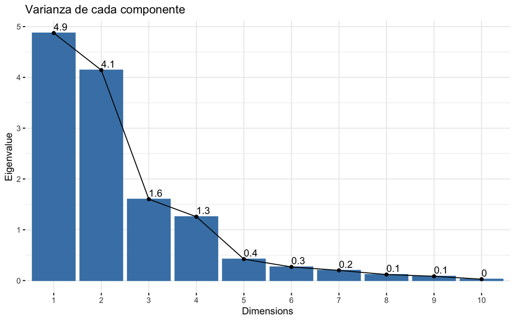

```r
fviz_eig(pca, main="Varianza de cada componente", choice = "eigenvalue", addlabels = T)
```

o como el porcentaje de varianza explicada por cada componente sobre el total.

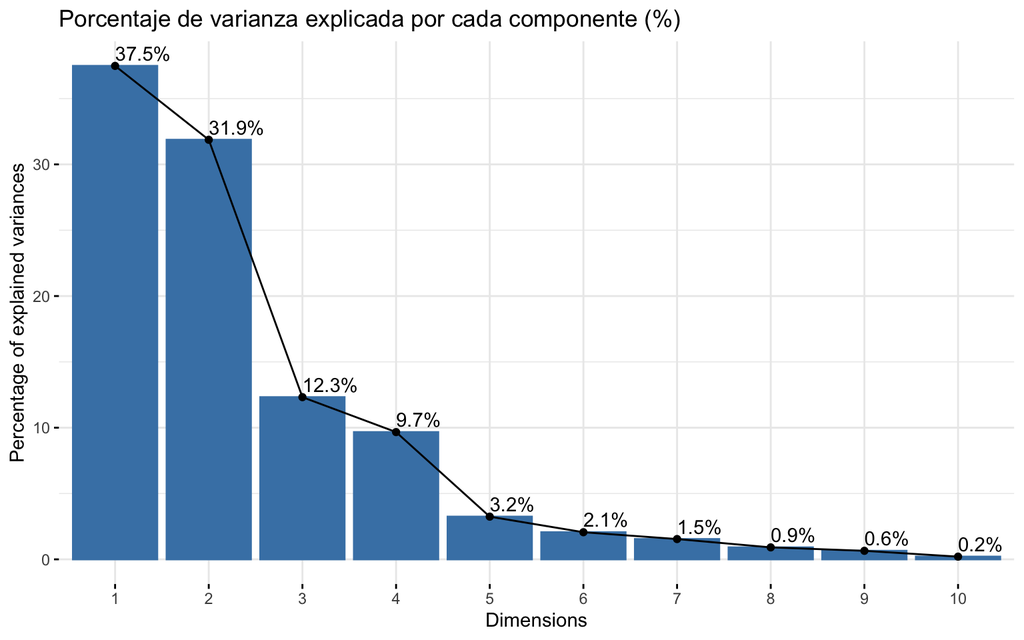

```r
fviz_screeplot(pca, addlabels = TRUE, main="Porcentaje de varianza explicada por cada componente (%)")
```

A continuación, representamos las varianzas acumuladas:

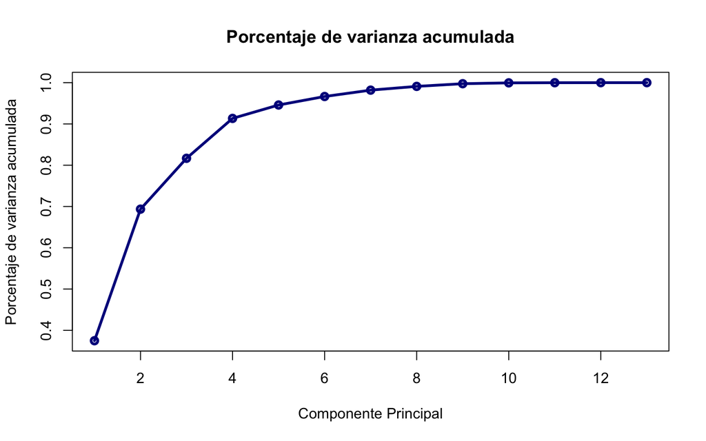

```r
plot(summary(pca)$importance[3, ], type="o", col="darkblue", lwd=3, main = "Porcentaje de varianza acumulada", xlab = "Componente Principal", ylab = "Porcentaje de varianza acumulada")
```

Determinar el número de componentes que elegir para continuar con el análisis no tiene unas normas determinadas a seguir. Respecto a ello, existen varios criterios con sus respectivas propuestas.

1. Una opción para determinar el número de componentes principales que seleccionar, es coger aquellas tal que expliquemos un % **determinado de la variabilidad de los datos que nosotros prefijemos**. Generalmente se pone como umbral mínimo un 80%, entonces necesitaríamos elegir 3 componentes.
2. Otra posibilidad es seguir el **criterio de Kaisser**, que escoge aquellas componentes cuyo autovalor sea superior a 1 (cuando las variables han sido generadas a partir de la matriz de correlaciones). Según este criterio y mirando el gráfico anterior de la varianza (igual a eigenvalues), eligiríamos las cuatro primeras componentes. Este criterio, cuando p < 20, tiende a ser estricto e incluir pocas componentes.
3. Para relajar el criterio de Kaisser, existe la **modificación de Jollife**, que elige aquellas componentes cuyo autovalor sea superior a 0.7. Esta modificación, nos permite elegir igualmente 4 componentes.

En este caso, nos podríamos quedar con las 4 primeras componentes principales, ya que es el número en el que coincide el mayor número de criterios. Por tanto, en lugar de trabajar con las 13 variables originales, trabajaremos con 4 variables nuevas, que son combinaciones de ellas.

## Interpretación

Hemos decidido quedarnos con 4 componentes principales, que explican el 91% de la variabilidad total. Para realizar su interpretación, volvemos a ver los coeficientes de las ecuaciones de los componentes, observando cuáles son los valores más altos (en valor absoluto), para así poder dar una interpretación a cada eje.

```r
# Autovectores de las primeras 3 componentes
cov(pca$rotation [,1:4])
```

```
##              PC1          PC2           PC3           PC4
## PC1  0.074284136  0.014541400  0.0029560973 -0.0029453827
## PC2  0.014541400  0.059966364 -0.0047502326  0.0047330151
## PC3  0.002956097 -0.004750233  0.0823676664  0.0009621668
## PC4 -0.002945383  0.004733015  0.0009621668  0.0823746540
```

```r
pca$rotation[,1:4]
```

```
##                              PC1         PC2         PC3         PC4
## HipotecaMedia         0.23447260 -0.06310254  0.60036701 -0.14352759
## IndicedeVivienda      0.35056462  0.03492200  0.33265184 -0.21595433
## TasaEjecHipotecarias  0.18895585 -0.38696171 -0.29859399 -0.04395518
## Hip100H               0.02384814 -0.32139415  0.21029632  0.52700520
## TasaParo              0.17638635  0.16978548 -0.45544384 -0.50048376
## TasaNatalidad         0.34697038  0.22377034 -0.16525154  0.33885102
## NumHip                0.23253409 -0.41264772 -0.06210480 -0.03592632
## VV100H               -0.31862705 -0.19954134 -0.24466170  0.14612450
## IndEnvej             -0.38398575 -0.20108861  0.16993058 -0.09362279
## TasaMortalidad       -0.39081025 -0.14283197 -0.08256307  0.03905432
## TasaFecundidad        0.27908332  0.21917010 -0.19293982  0.49563579
## Activos               0.22264109 -0.41490535 -0.05417093 -0.08779747
## Compravent            0.22610583 -0.41442757 -0.14564495 -0.03868128
```

## Representación gráfica

**Gráfico de las variables**

Representamos sobre las dos primeras componentes principales las variables originales. En el eje de abscisas se representa la PC1 y en el eje de ordenadas, la PC2. Para interpretar correctamente las variables tenemos que fijarnos en la longitud de la flecha y en el ángulo que forman respecto a los ejes y entre ellos mismos.

- **Ángulo vector - eje**: cuanto más paralelo es un vector al eje, más ha contribuido a dicha componente principal.
- **Ángulo entre dos vectores**: si es pequeño representa una alta correlación entre las variables implicadas (y por tanto, observaciones con valores altos en una variable, tendrá valores altos en la otra). Si el ángulo es cercano a 90º indica que las variables están incorreladas y los ángulos opuestos indican correlación negativa entre ellas.
- **Longitud**: cuanto mayor es la longitud de un vector, mayor varianza de la variable está contenida en el biplot, es decir, mejor representada está en el gráfico.

En el gráfico, diferenciamos por colores las variables según su calidad de representación en las dos primeras componentes. Cuanto más cerca esté una variable del círculo de correlaciones, mejor será su representación, por lo que las variables que estén muy cerca del centro de la gráfica son las menos importantes para las dos primeras componentes.

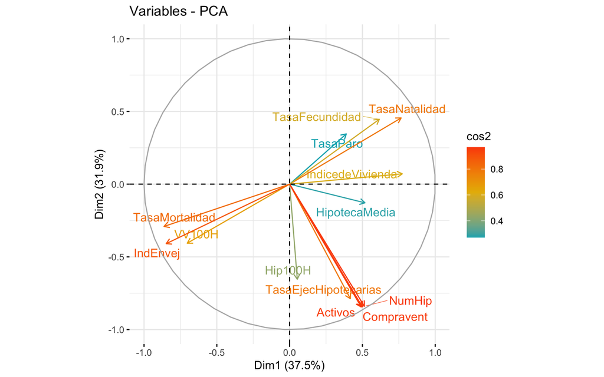

```r
fviz_pca_var(pca,axes=c(1,2), col.var = "cos2", gradient.cols = c("#00AFBB", "#E7B800", "#FC4E07"), repel = TRUE)
```

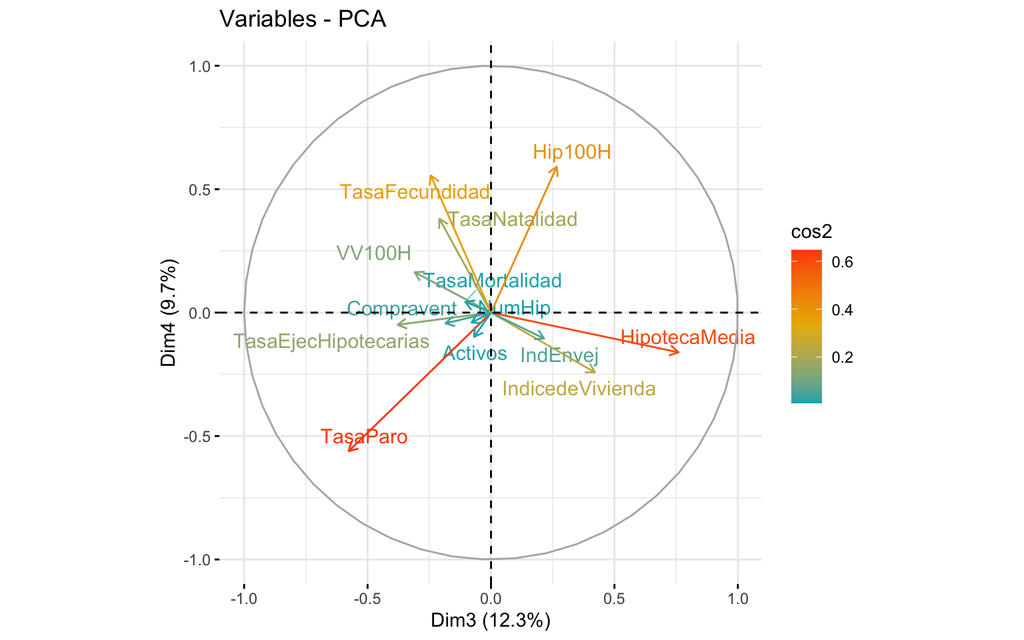

```r
fviz_pca_var(pca,axes=c(3,4), col.var = "cos2", gradient.cols = c("#00AFBB", "#E7B800", "#FC4E07"), repel = TRUE)
```

**RESUMEN DE RESULTADOS**

Los gráficos obtenidos muestran una visualización de las variables en función de las componentes principales 1 y 2, y 3 y 4. Las variables que tienen una correlación alta con la primera (y tercera) componente principal están más cerca del eje horizontal y las variables que tienen una alta correlación con la segunda componente principal(y cuarta) están más cerca del eje vertical. Las variables que se encuentran cerca del centro del gráfico tienen una correlación baja con ambas componentes principales, aún así nos guiaremos con la tabla para decidir qué variables están mejor explicadas por cada una de las componentes. En resumen, estos gráficos proporcionan una representación visual de las relaciones entre las variables en función de las dos primeras componentes principales y las dos segundas, lo que puede ayudar a identificar patrones y tendencias en los datos.

**COMPONENTE 1**

El índice del precio de la vivienda es un indicador importante para el mercado hipotecario ya que afecta el costo de las hipotecas y la capacidad de los compradores para obtener financiamiento. Si el precio de la vivienda es alto, es posible que las personas tengan dificultades para pagar su hipoteca y, por lo tanto, se reducirá la demanda de préstamos hipotecarios.

El número de viviendas vacías por comunidad autónoma por cada 100 mil habitantes también es un factor importante en el mercado hipotecario. Si hay muchas viviendas vacías en una determinada área, es posible que el valor de las propiedades disminuya, lo que puede dificultar la venta de propiedades y la obtención de préstamos hipotecarios.

El índice de envejecimiento, por su parte, puede tener un impacto en la demanda de viviendas en el mercado hipotecario. Si hay una población envejecida en una determinada área, es posible que haya menos demanda de viviendas, lo que puede disminuir el valor de las propiedades y hacer que sea más difícil obtener financiamiento.

En conjunto, la primera componente parece estar relacionada con la oferta y la demanda de viviendas en el mercado hipotecario y, por lo tanto, podría ser importante para entender las condiciones del mercado inmobiliario en una determinada región. El nombre de la componente podría ser “**Indicadores del mercado hipotecario**”.

**COMPONENTE 2**

Tasa de ejecuciones hipotecarias: Este indicador mide la cantidad de ejecuciones hipotecarias que se han llevado a cabo en una determinada región en un periodo de tiempo específico. La tasa de ejecuciones hipotecarias puede reflejar la salud del mercado inmobiliario y la capacidad de los prestatarios para cumplir con sus pagos hipotecarios. Si la tasa de ejecuciones hipotecarias es alta, esto puede indicar que hay un mayor riesgo crediticio en la región y puede afectar la percepción de los prestamistas y compradores de vivienda.

Número de hipotecas por comunidad autónoma: Este indicador mide la cantidad de hipotecas concedidas en una determinada región en un periodo de tiempo específico. El número de hipotecas puede reflejar la salud del mercado inmobiliario y la demanda de vivienda en la región. Si el número de hipotecas es alto, esto puede indicar una mayor actividad en el mercado hipotecario y una mayor demanda de vivienda en la región.

Número de personas activas (Encuesta EPA): La Encuesta de Población Activa (EPA) es una encuesta que mide el número de personas en edad laboral que están trabajando o buscando trabajo. El número de personas activas puede tener un impacto en el mercado hipotecario, ya que si hay muchas personas empleadas en una determinada región, es posible que haya una mayor capacidad de los prestatarios para cumplir con sus pagos hipotecarios y una mayor demanda de vivienda en la región.

Número de viviendas adquiridas en compraventa en el año 2021 por comunidad autónoma: Este indicador mide la cantidad de viviendas que se han comprado y vendido en una determinada región durante el año 2021. Este dato puede reflejar la actividad en el mercado inmobiliario y la demanda de vivienda en la región. Si el número de viviendas adquiridas en compraventa es alto, esto puede indicar una mayor actividad en el mercado hipotecario y una mayor demanda de vivienda en la región.

Teniendo en cuenta las variables que componen la segunda componente, un posible nombre resumen podría ser “**Riesgo Hipotecario**”. Esta componente refleja tanto la actividad en el mercado hipotecario, medida por el número de hipotecas y viviendas adquiridas en compraventa, como la estabilidad del mercado, medida por la tasa de ejecuciones hipotecarias y el número de personas activas en la región.

**COMPONENTE 3**

Valor medio de las hipotecas: este indicador mide el valor promedio de las hipotecas concedidas en una determinada región en un periodo de tiempo específico. El valor medio de las hipotecas puede ser un indicador de la capacidad de los prestatarios para obtener financiación y adquirir una vivienda en la región.

Tasa de desempleo: este indicador mide la proporción de personas en edad laboral que están desempleadas en una determinada región en un periodo de tiempo específico. La tasa de desempleo puede tener un impacto en el mercado hipotecario, ya que si hay muchas personas desempleadas en la región, es posible que haya una menor capacidad de los prestatarios para cumplir con sus pagos hipotecarios.

En conjunto, estas variables pueden proporcionar información sobre la **salud (estabilidad) financiera** de los prestatarios en la región y su capacidad para afrontar los pagos hipotecarios.

**COMPONENTE 4**

Número de hipotecas por cada 100.000 habitantes: este indicador mide el número de hipotecas concedidas en una determinada región en relación con el número de habitantes de la misma. Este indicador puede proporcionar información sobre la actividad del mercado hipotecario en la región y la demanda de viviendas.

Tasa de natalidad: este indicador mide la proporción de nacimientos en una determinada región en relación con el número total de habitantes. La tasa de natalidad puede ser un indicador de la demanda futura de viviendas, ya que las parejas jóvenes que tienen hijos suelen buscar viviendas más grandes y espaciosas para acomodar a sus familias.

Tasa de fecundidad: este indicador mide el número promedio de hijos por mujer en una determinada región. La tasa de fecundidad también puede ser un indicador de la demanda futura de viviendas, ya que si la tasa de fecundidad es alta, puede haber una mayor demanda de viviendas más grandes y espaciosas.

En conjunto, estas variables pueden proporcionar información sobre la actividad del mercado hipotecario en la región y la **demanda futura** de viviendas.

En el siguiente gráfico podemos ver las correlaciones de dichas variables con las componentes principales, como ya hemos comentado.

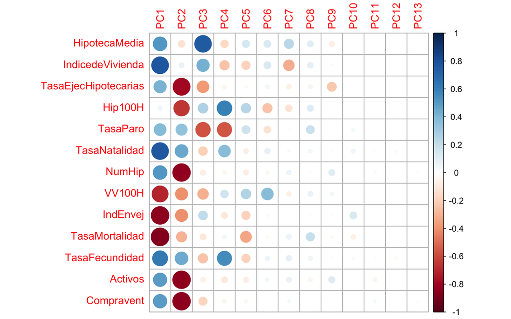

```r
corr_var <- pca$rotation %*% diag(pca$sdev)
colnames(corr_var) <- c("PC1", "PC2", "PC3", "PC4", "PC5", "PC6", "PC7", "PC8", "PC9", "PC10", "PC11", "PC12", "PC13")
corrplot(corr_var)
```

En cuanto a este gráfico, es llamativo como las tres o cuatro primeras componentes son las más importantes en el PCA, sobre todo, la PC1.

En resumen, las nuevas componentes han permitido identificar patrones y características de las comunidades autónomas en términos de mercado hipotecario, riesgo hipotecario, estabilidad financiera y demanda futura. Este análisis proporciona información valiosa para comprender mejor las diferencias y similitudes entre las comunidades autónomas y puede ser útil para tomar decisiones en términos de políticas públicas y estrategias empresariales.

**Gráfico de los individuos**

Tras observar la representación de las variables, en este apartado vemos la representación de los individuos sobre los nuevos ejes, con la idea de que aquellos con características similares, se agrupan cerca al tener puntuaciones parecidas. Las comunidades con valores cercanos a la media se situarán cerca del centro del gráfico (0,0).

Representando los individuos sobre PC1 y PC2, vemos que Comunidades como Ceuta y Melilla, o Cataluña y el Madrid están muy próximas entre sí, indicando que tienden a tener un nivel de Mercado de Hipotécas similar.

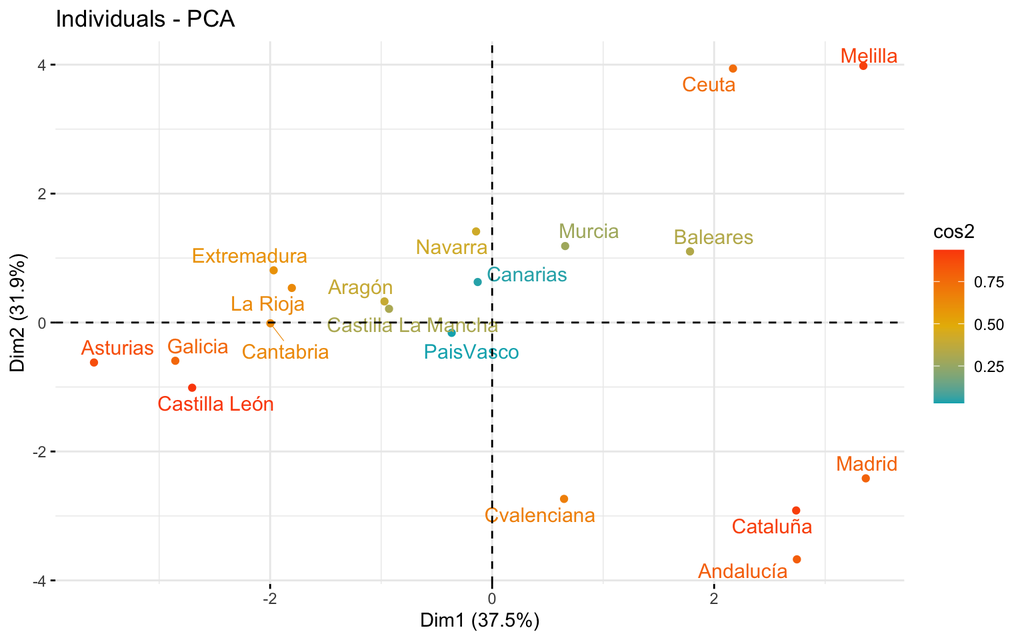

```r
# Sobre PC1 y PC2
fviz_pca_ind(pca, col.ind = "cos2", gradient.cols = c("#00AFBB", "#E7B800", "#FC4E07"), repel = TRUE, axes = c(1, 2))
```

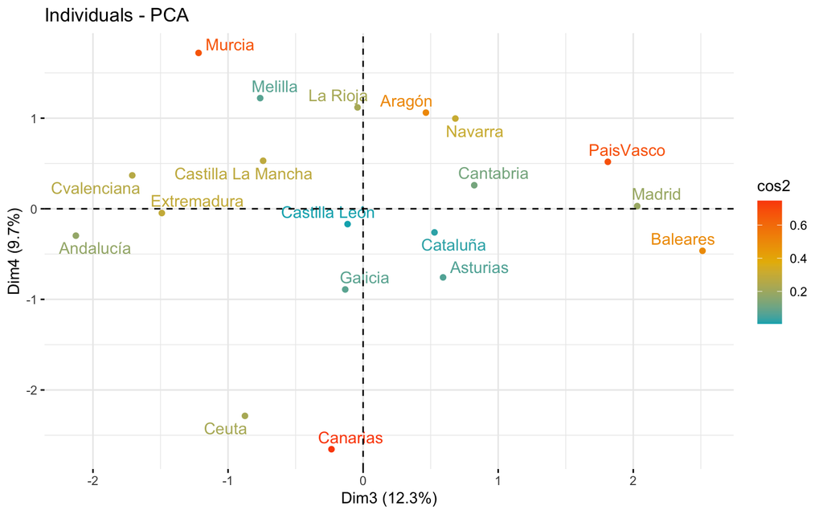

```r
fviz_pca_ind(pca, col.ind = "cos2", gradient.cols = c("#00AFBB", "#E7B800", "#FC4E07"), repel = TRUE, axes = c(3, 4))
```

# Conclusiones

Las nuevas componentes han permitido analizar las características más destacadas de las comunidades autónomas en términos del mercado hipotecario, el riesgo hipotecario, la estabilidad financiera y la demanda futura.

# Conclusiones

En resumen, las nuevas componentes han permitido identificar patrones y características de las comunidades autónomas en términos de mercado hipotecario, riesgo hipotecario, estabilidad financiera y demanda futura. Este análisis proporciona información valiosa para comprender mejor las diferencias y similitudes entre las comunidades autónomas y puede ser útil para tomar decisiones en términos de políticas públicas y estrategias empresariales.

[^1]: EDA viene del Inglés *Exploratory Data Analysis* y son los pasos relativos en los que se exploran las variables para tener una idea de que forma toma el dataset.